# hybrid_recommender

## Setup

Install required packages:

```
pip install pandas numpy scipy scikit-learn implicit streamlit tqdm matplotlib seaborn
```

## Import Libraries

Standard data science libraries for dataframe operations, sparse matrices, text vectorization, and the `implicit` library for ALS (Alternating Least Squares) collaborative filtering.

```python
import pandas as pd
import scipy.sparse as sps
from sklearn.feature_extraction.text import TfidfVectorizer
import implicit
import pickle
from pathlib import Path
from sklearn.metrics.pairwise import cosine_similarity
import numpy as np
import matplotlib.pyplot as plt
import seaborn as sns
from tqdm import tqdm

sns.set_style("whitegrid")
```

## Set Up Data Paths

Define where the MovieLens data is stored and create an `artifacts/` directory to save the trained model.

```python
data_dir = Path("data/")
artifacts_dir = Path("artifacts")
artifacts_dir.mkdir(exist_ok=True)
```

## Load Raw Data

Load three datasets from MovieLens-32M:

- **ratings**: User ratings (userId, movieId, rating, timestamp)
- **movies**: Movie metadata (movieId, title, genres)
- **tags**: User-generated tags for movies (userId, movieId, tag, timestamp)

```python
ratings = pd.read_csv(data_dir / "ml-32m/ratings.csv")
movies = pd.read_csv(data_dir / "ml-32m/movies.csv")
tags = pd.read_csv(data_dir / "ml-32m/tags.csv")

print(f"Loaded {len(ratings)} ratings, {len(movies)} movies, {len(tags)} tags")
```

```
Loaded 32000204 ratings, 87585 movies, 2000072 tags
```

```python
top_movies = (
    ratings["movieId"].value_counts().head(1000).index.tolist()
)  # list of movieIds

print(f"Selected top {len(top_movies)} movies")
```

```
Selected top 1000 movies
```

## Subset Data and Downsample Ratings

Keep only data related to the top 1000 movies, then downsample ratings to 50% for faster training. This reduces the dataset from millions of ratings to a manageable size while maintaining the collaborative signal.

```python
movies = movies[movies["movieId"].isin(top_movies)]
ratings = ratings[ratings["movieId"].isin(top_movies)]
ratings = ratings.sample(frac=0.5, random_state=42)
tags = tags[tags["movieId"].isin(top_movies)]

print(
    f"After filtering: {len(ratings)} ratings, {len(movies)} movies, {len(tags)} tags"
)
```

```
After filtering: 9439196 ratings, 1000 movies, 704287 tags
```

## Build Movie ID Mappings

Map raw MovieLens movieId to contiguous indices (0..n-1) and back. Only include movies that remain after filtering/downsampling so indices align with the ALS input.

```python
movie_ids_in_ratings = sorted(ratings["movieId"].unique().tolist())
movie_2_index = {mid: idx for idx, mid in enumerate(movie_ids_in_ratings)}
index_2_movie = {idx: mid for mid, idx in movie_2_index.items()}

print(f"DEBUG: movie_ids_in_ratings has {len(movie_ids_in_ratings)} movies")
```

```
DEBUG: movie_ids_in_ratings has 1000 movies
```

## Build User ID Mappings

Similarly, create dense user indices for the collaborative filtering model.

```python
user_ids_in_ratings = sorted(ratings["userId"].unique().tolist())
user_2_index = {uid: idx for idx, uid in enumerate(user_ids_in_ratings)}
index_2_user = {idx: uid for uid, idx in user_2_index.items()}

print(f"DEBUG: user_ids_in_ratings has {len(user_ids_in_ratings)} users")
```

```
DEBUG: user_ids_in_ratings has 200758 users
```

## Build User-Rating Matrix

Construct a sparse user-rating matrix (users × items) in CSR format. This is the core input for the ALS algorithm. Each cell contains the rating value, and sparse storage keeps memory efficient since most user-movie pairs are not rated.

```python
rows = ratings["userId"].map(user_2_index)
cols = ratings["movieId"].map(movie_2_index)
data = ratings["rating"].astype(float)
user_rating_matrix = sps.csr_matrix(
    (data, (rows, cols)), shape=(len(user_2_index), len(movie_2_index))
)

print(f"DEBUG: user_rating_matrix shape is {user_rating_matrix.shape}")
print(
    f"DEBUG: user_rating_matrix has {user_rating_matrix.nnz} non-zero entries"
)
print(
    f"DEBUG: Sparsity: {1 - (user_rating_matrix.nnz / (user_rating_matrix.shape[0] * user_rating_matrix.shape[1]))*100:.2f}%"
)
```

```
DEBUG: user_rating_matrix shape is (200758, 1000)
DEBUG: user_rating_matrix has 9439196 non-zero entries
DEBUG: Sparsity: -3.70%
```

### Rating Distribution

Visualize the distribution of ratings to understand user behavior.

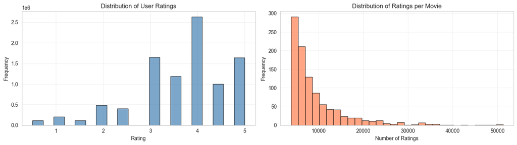

```python
fig, axes = plt.subplots(1, 2, figsize=(14, 4))

axes[0].hist(
    ratings["rating"], bins=20, edgecolor="black", alpha=0.7, color="steelblue"
)
axes[0].set_xlabel("Rating")
axes[0].set_ylabel("Frequency")
axes[0].set_title("Distribution of User Ratings")
axes[0].grid(alpha=0.3)

ratings_per_movie = ratings["movieId"].value_counts()
axes[1].hist(
    ratings_per_movie, bins=30, edgecolor="black", alpha=0.7, color="coral"
)
axes[1].set_xlabel("Number of Ratings")
axes[1].set_ylabel("Frequency")
axes[1].set_title("Distribution of Ratings per Movie")
axes[1].grid(alpha=0.3)

plt.tight_layout()
plt.show()
```

## Enrich Movies with Tags

Aggregate user-generated tags by movie and combine them with title and genres into a single "content" field. This text will be used for TF-IDF vectorization to compute content-based similarity.

```python
movie_tags = (
    tags.groupby("movieId")["tag"]
    .apply(lambda ts: " ".join(ts.astype(str)))
    .reset_index()
)
movies = movies.merge(movie_tags, how="left", on="movieId")
movies["tag"] = movies["tag"].fillna("")

movies["genres_clean"] = (
    movies["genres"].fillna("").str.replace("|", " ", regex=False)
)
movies["content"] = (
    movies["title"].fillna("")
    + " "
    + movies["genres_clean"]
    + " "
    + movies["tag"]
)

print(f"Sample content field:\n{movies['content'].iloc[0]}\n")
```

```
Sample content field:
Toy Story (1995) Adventure Animation Children Comedy Fantasy children Disney animation children Disney Disney pixar animation funny Pixar Pixar Tumey's To See Again Tumey's VHS adventure classic friendship funny animation computer animation pixar toys adventure computer animation Pixar adventure ani…
```

## Filter and Reindex Movies

Filter movies to only those that survived rating downsampling, then reindex them to match the dense item indices (0 to n_items-1). This ensures the movie metadata aligns perfectly with the collaborative filtering model indices.

```python
movies = movies[movies["movieId"].isin(movie_ids_in_ratings)]

print(f"DEBUG: movies dataframe has {len(movies)} movies after filtering")

movies_indexed = (
    movies.set_index("movieId").reindex(movie_ids_in_ratings).reset_index()
)
for col in ["title", "genres", "content"]:
    if col in movies_indexed.columns:
        movies_indexed[col] = movies_indexed[col].fillna("")

print(f"DEBUG: movies_indexed has {len(movies_indexed)} movies")
```

```
DEBUG: movies dataframe has 1000 movies after filtering
DEBUG: movies_indexed has 1000 movies
```

## Compute TF-IDF Vectors

#### How does TF-IDF work?

TF-IDF (Term Frequency-Inverse Document Frequency) is a statistical measure used to evaluate the importance of a word in a 'document' relative to a collection of documents (corpus). It helps in identifying the most relevant terms in a document while down-weighting common terms.

Now, we convert movie content (title + genres + tags) into TF-IDF vectors. This represents each movie as a sparse vector in a 5000-dimensional feature space, capturing term importance while removing common stop words.

```python
tfidf = TfidfVectorizer(max_features=5000, stop_words="english")
item_content = tfidf.fit_transform(movies_indexed["content"])

print(f"TF-IDF matrix shape: {item_content.shape}")
print(f"Number of features: {len(tfidf.get_feature_names_out())}")
```

```
TF-IDF matrix shape: (1000, 5000)
Number of features: 5000
```

Quick check to see which words the TF‑IDF vectorizer thinks are most important for Star Wars films.

The cell finds movies with "Star Wars" in the title and prints their titles and genres.

It pulls the TF‑IDF rows for those movies and converts them to dense arrays (safe because it is only a few rows).

For each movie it picks the top `top_n` terms, unions those indices, and filters the TF‑IDF matrix to just those terms.

It then draws a heatmap where each row is a Star Wars movie and each column is a picked term, with TF‑IDF scores annotated.

Interesting to see that "jar" and "binks" (as in Jar Jar Binks) are picked up as important for "The Phantom Menace"!

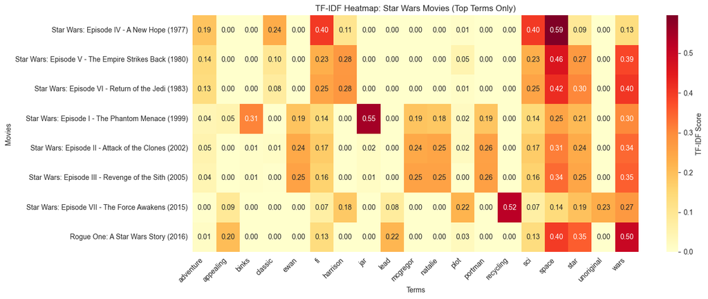

```python
star_wars_mask = movies_indexed["title"].str.contains(
    "Star Wars", case=False, na=False
)
star_wars_movies = movies_indexed[star_wars_mask]

star_wars_indices = star_wars_movies.index.tolist()

star_wars_tfidf = item_content[star_wars_indices].toarray()

feature_names = tfidf.get_feature_names_out()

top_n = 5
all_top_terms = set()
for row in star_wars_tfidf:
    top_indices = np.argsort(row)[-top_n:]
    all_top_terms.update(top_indices)

all_top_terms = sorted(list(all_top_terms))

star_wars_tfidf_filtered = star_wars_tfidf[:, all_top_terms]
filtered_feature_names = feature_names[all_top_terms]

fig, ax = plt.subplots(figsize=(15, 6))
sns.heatmap(
    star_wars_tfidf_filtered,
    xticklabels=filtered_feature_names,
    yticklabels=[movies_indexed.loc[i, "title"] for i in star_wars_indices],
    cmap="YlOrRd",
    annot=True,
    fmt=".2f",
    cbar_kws={"label": "TF-IDF Score"},
    ax=ax,
    vmin=0,
)
plt.title("TF-IDF Heatmap: Star Wars Movies (Top Terms Only)")
plt.xlabel("Terms")
plt.ylabel("Movies")
plt.xticks(rotation=45, ha="right")
plt.tight_layout()
plt.show()
```

## Train ALS Collaborative Filtering Model

Now, we train an implicit ALS model on the confidence-weighted rating matrix. The `alpha=40` weight amplifies explicit ratings into confidence scores (implicit feedback). The model learns 64-dimensional latent factors for both users and items, using regularization to prevent overfitting.

```python
alpha = 40.0
conf = (user_rating_matrix * alpha).astype("double")
model = implicit.als.AlternatingLeastSquares(
    factors=64, regularization=0.1, iterations=20
)
model.fit(conf)
```

## Extract Learned Factors

Extract the learned latent factor matrices from the trained model. These dense vectors represent movies and users in the learned latent space and are used for collaborative filtering recommendations.

```python
item_factors = model.item_factors  # shape: n_items x k
user_factors = model.user_factors  # shape: n_users x k

print(f"DEBUG: item_factors shape is {item_factors.shape}")
print(f"DEBUG: user_factors shape is {user_factors.shape}")
```

```
DEBUG: item_factors shape is (1000, 64)
DEBUG: user_factors shape is (200758, 64)
```

### Latent Factor Analysis

Visualize the distribution and correlations of learned latent factors.

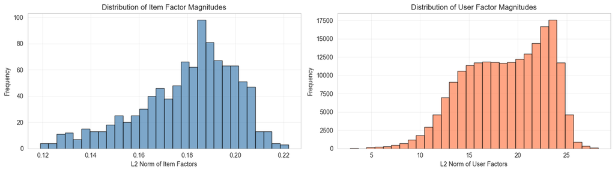

```python
fig, axes = plt.subplots(1, 2, figsize=(14, 4))

item_magnitudes = np.linalg.norm(item_factors, axis=1)
axes[0].hist(
    item_magnitudes, bins=30, edgecolor="black", alpha=0.7, color="steelblue"
)
axes[0].set_xlabel("L2 Norm of Item Factors")
axes[0].set_ylabel("Frequency")
axes[0].set_title("Distribution of Item Factor Magnitudes")
axes[0].grid(alpha=0.3)

user_magnitudes = np.linalg.norm(user_factors, axis=1)
axes[1].hist(
    user_magnitudes, bins=30, edgecolor="black", alpha=0.7, color="coral"
)
axes[1].set_xlabel("L2 Norm of User Factors")
axes[1].set_ylabel("Frequency")
axes[1].set_title("Distribution of User Factor Magnitudes")
axes[1].grid(alpha=0.3)

plt.tight_layout()
plt.show()
```

## Compute Content-Based Similarity

Compute a sparse item-item similarity matrix using cosine similarity of TF-IDF vectors. This captures which movies are similar based on their textual features (title, genres, tags).

```python
item_content = tfidf.transform(movies_indexed["content"])  # already aligned
cosine_sim = cosine_similarity(
    item_content, item_content, dense_output=False
)  # shape: n_items x n_items

print(f"DEBUG: cosine_sim shape is {cosine_sim.shape}")
```

```
DEBUG: cosine_sim shape is (1000, 1000)
```

### What this plot shows

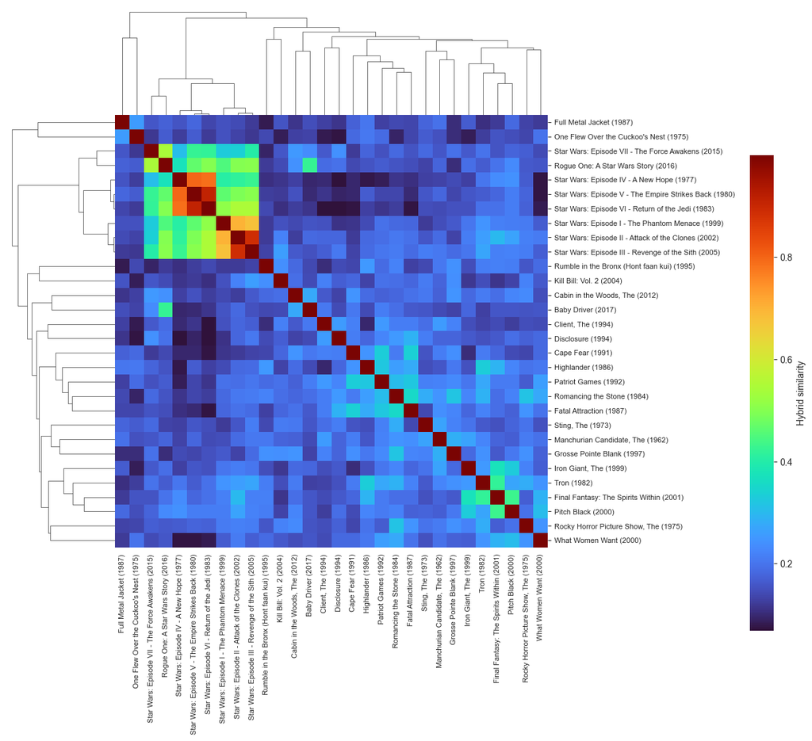

```python
n_display = min(30, item_factors.shape[0])
alpha = 0.5

cf_sim = cosine_similarity(item_factors)  # dense n_items x n_items

cosine_sim_dense = (
    cosine_sim.toarray()
    if hasattr(cosine_sim, "toarray")
    else np.asarray(cosine_sim)
)


def normalize_mat(m):
    mn, mx = m.min(), m.max()
    return (m - mn) / (mx - mn) if mx > mn else np.zeros_like(m)


cf_norm = normalize_mat(cf_sim)
costine_norm = normalize_mat(cosine_sim_dense)

hybrid_sim = alpha * cf_norm + (1.0 - alpha) * costine_norm

# Ensure all "star wars" movies are included
titles_all = movies_indexed["title"].fillna("").astype(str).tolist()
star_wars_indices = [
    i for i, title in enumerate(titles_all) if "star wars" in title.lower()
]

if len(star_wars_indices) >= n_display:
    indices = np.random.choice(
        star_wars_indices, size=n_display, replace=False
    )
else:
    remaining_pool = np.setdiff1d(
        np.arange(item_factors.shape[0]), star_wars_indices
    )
    n_remaining = n_display - len(star_wars_indices)
    random_indices = np.random.choice(
        remaining_pool, size=n_remaining, replace=False
    )
    indices = np.concatenate([star_wars_indices, random_indices])

hybrid_sub = hybrid_sim[np.ix_(indices, indices)]

labels = [titles_all[i] if titles_all[i] != "" else str(i) for i in indices]

g = sns.clustermap(
    hybrid_sub,
    method="weighted",  # options: single, complete, average, weighted, centroid, median, ward
    metric="cosine",
    cmap="turbo",
    figsize=(12, 12),
    xticklabels=labels,
    yticklabels=labels,
    cbar_kws={"label": "Hybrid similarity"},
)

plt.setp(g.ax_heatmap.get_xticklabels(), rotation=90, fontsize=8)
plt.setp(g.ax_heatmap.get_yticklabels(), rotation=0, fontsize=8)
g.cax.set_position([0.95, 0.2, 0.03, 0.6])

plt.show()
```

Interesting to see that we have two groups of Star Wars movies clustering together, one for the original trilogy and one for the prequels, indicating that both collaborative filtering and content-based features recognize their similarity.

## Sanity Checks

Verify that all components have matching dimensions. This ensures consistency across collaborative factors, content similarity, movie metadata, and ID mappings. A mismatch would cause errors in the Streamlit app.

```python
n_cf = item_factors.shape[0]
n_content = cosine_sim.shape[0]
n_movies = len(movies_indexed)
n_map = len(index_2_movie)

print(f"\n=== FINAL DIMENSIONS ===")
print(f"item_factors: {n_cf}")
print(f"cosine_sim: {n_content}")
print(f"movies_indexed: {n_movies}")
print(f"i2m: {n_map}")

if n_cf == n_content == n_movies == n_map:
    print(f"Sanity check passed: all have {n_cf} items")
else:
    print(f"\nMISMATCH")
    print(
        f"   item_factors is from user_rating_matrix which has {URM.shape[1]} items"
    )
    print(f"   But we're trying to match {len(movie_ids_in_ratings)} movies")
    raise ValueError(
        f"Dimension mismatch! item_factors={n_cf}, cosine_sim={n_content}, "
        f"movies_indexed={n_movies}, i2m={n_map}. All should be equal!"
    )
```

```
=== FINAL DIMENSIONS ===
item_factors: 1000
cosine_sim: 1000
movies_indexed: 1000
i2m: 1000
Sanity check passed: all have 1000 items
```

## Model Evaluation

```python
np.random.seed(42)
test_fraction = 0.2
test_indices = np.random.choice(
    user_rating_matrix.nnz,
    size=int(user_rating_matrix.nnz * test_fraction),
    replace=False,
)

test_data = np.zeros(user_rating_matrix.nnz)
train_data = user_rating_matrix.data.copy()

for idx in test_indices:
    test_data[idx] = train_data[idx]
    train_data[idx] = 0.0

user_rating_matrix_train = sps.csr_matrix(
    (train_data, user_rating_matrix.indices, user_rating_matrix.indptr),
    shape=user_rating_matrix.shape,
)
user_rating_matrix_test = sps.csr_matrix(
    (test_data, user_rating_matrix.indices, user_rating_matrix.indptr),
    shape=user_rating_matrix.shape,
)

print(f"Train set: {user_rating_matrix_train.nnz} ratings")
print(f"Test set: {user_rating_matrix_test.nnz} ratings")
```

```
Train set: 9439196 ratings
Test set: 9439196 ratings
```

### Compute Hit Rate and NDCG

For each test user, generate top-k recommendations and compare against held-out test ratings.

The hit-rate is defined as the fraction of test users for who at least one held-out item appears in the top-k recommendations. For a single user it is 1.0 if any test item is present in the top-k list and 0.0 otherwise; the reported Hit Rate@k is the average across users.

NDCG (Normalized Discounted Cumulative Gain) measures ranking quality by giving higher weight to relevant items appearing higher in the recommendation list. Essentially, the higher the relevance-weighted items appear near the top of the recommendation list, the higher the NDCG, the better the recommendation.

Both metrics are averaged across users to produce the final Hit Rate@k and NDCG@k.

```python
def compute_hit_rate_and_ndcg(
    model_item_factors, user_rating_matrix_train, user_rating_matrix_test, k=10
):
    """
    Compute hit rate and NDCG for top-k recommendations.
    """
    hit_rates = []
    ndcgs = []

    test_users = np.where(user_rating_matrix_test.getnnz(axis=1) > 0)[
        0
    ]  # users with test ratings

    for user_idx in tqdm(
        test_users[: min(100, len(test_users))], desc="Evaluating"
    ):
        user_trained_items = user_rating_matrix_train[user_idx].nonzero()[1]
        if len(user_trained_items) == 0:
            continue

        user_vec = model_item_factors[user_trained_items].mean(axis=0)

        scores = model_item_factors.dot(user_vec)

        train_items = set(user_rating_matrix_train[user_idx].nonzero()[1])
        ranked = sorted(
            (
                (i, scores[i])
                for i in range(len(scores))
                if i not in train_items
            ),
            key=lambda x: -x[1],
        )[:k]

        top_k_items = [i for i, _ in ranked]

        test_items = set(user_rating_matrix_test[user_idx].nonzero()[1])

        # any test item in top-k?
        hits = len(set(top_k_items) & test_items)
        hit_rate = 1.0 if hits > 0 else 0.0
        hit_rates.append(hit_rate)

        # NDCG
        dcg = sum(
            [
                1.0 / np.log2(i + 2)
                for i, item in enumerate(top_k_items)
                if item in test_items
            ]
        )
        idcg = sum(
            [1.0 / np.log2(i + 2) for i in range(min(len(test_items), k))]
        )
        ndcg = dcg / idcg if idcg > 0 else 0.0
        ndcgs.append(ndcg)

    return np.mean(hit_rates), np.mean(ndcgs)


hit_rate, ndcg = compute_hit_rate_and_ndcg(
    item_factors, user_rating_matrix_train, user_rating_matrix_test, k=10
)

print(f"\n=== EVALUATION METRICS (k=10) ===")
print(f"Hit Rate@10: {hit_rate:.4f}")
print(f"NDCG@10: {ndcg:.4f}")
```

```
=== EVALUATION METRICS (k=10) ===
Hit Rate@10: 0.3400
NDCG@10: 0.0738
```

### Evaluation Visualization

```python
compute_hit_rate_and_ndcg(
    item_factors, user_rating_matrix_train, user_rating_matrix_test, k=10
)
```

```
(np.float64(0.34), np.float64(0.07378929909770875))
```

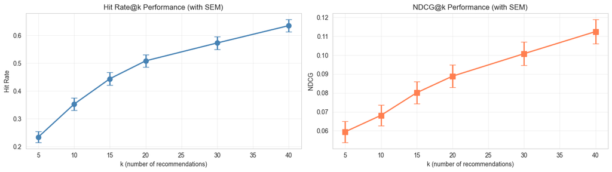

```python
def per_user_metrics(item_factors, URM_train, URM_test, k=10, max_users=500):
    test_users = np.where(URM_test.getnnz(axis=1) > 0)[0]
    if len(test_users) == 0:
        return np.array([]), np.array([])
    test_users = test_users[: min(max_users, len(test_users))]

    hits_list = []
    ndcgs = []

    for u in test_users:
        train_items = URM_train[u].nonzero()[1]
        test_items = set(URM_test[u].nonzero()[1])
        if len(train_items) == 0 or len(test_items) == 0:
            continue

        user_vec = item_factors[train_items].mean(axis=0)
        scores = item_factors.dot(user_vec)
        scores[list(train_items)] = -np.inf

        top_k = np.argsort(-scores)[:k]

        hit = 1.0 if any(i in test_items for i in top_k) else 0.0
        hits_list.append(hit)

        dcg = sum(
            1.0 / np.log2(idx + 2)
            for idx, item in enumerate(top_k)
            if item in test_items
        )
        idcg = sum(
            1.0 / np.log2(i + 2) for i in range(min(len(test_items), k))
        )
        ndcg = dcg / idcg if idcg > 0 else 0.0
        ndcgs.append(ndcg)

    return np.array(hits_list), np.array(ndcgs)


k_values = [5, 10, 15, 20, 30, 40]
hit_means = []
hit_sems = []
ndcg_means = []
ndcg_sems = []

for k in k_values:
    hits, ndcgs = per_user_metrics(
        item_factors,
        user_rating_matrix_train,
        user_rating_matrix_test,
        k=k,
        max_users=500,
    )
    if len(hits) == 0:
        hit_means.append(0.0)
        hit_sems.append(0.0)
        ndcg_means.append(0.0)
        ndcg_sems.append(0.0)
        continue

    hit_means.append(hits.mean())
    hit_sems.append(
        hits.std(ddof=1) / np.sqrt(len(hits)) if len(hits) > 1 else 0.0
    )

    ndcg_means.append(ndcgs.mean())
    ndcg_sems.append(
        ndcgs.std(ddof=1) / np.sqrt(len(ndcgs)) if len(ndcgs) > 1 else 0.0
    )


fig, axes = plt.subplots(1, 2, figsize=(14, 4))

axes[0].errorbar(
    k_values,
    hit_means,
    yerr=hit_sems,
    marker="o",
    linewidth=2,
    markersize=8,
    color="steelblue",
    capsize=5,
)
axes[0].set_xlabel("k (number of recommendations)")
axes[0].set_ylabel("Hit Rate")
axes[0].set_title("Hit Rate@k Performance (with SEM)")
axes[0].grid(alpha=0.3)

axes[1].errorbar(
    k_values,
    ndcg_means,
    yerr=ndcg_sems,
    marker="s",
    linewidth=2,
    markersize=8,
    color="coral",
    capsize=5,
)
axes[1].set_xlabel("k (number of recommendations)")
axes[1].set_ylabel("NDCG")
axes[1].set_title("NDCG@k Performance (with SEM)")
axes[1].grid(alpha=0.3)

plt.tight_layout()
plt.show()
```

This is a pretty good model. Let's save it for later use in the Streamlit app!

## Save Model Artifacts

Bundle all trained components into a single pickle file. This includes:

- The ALS model itself
- ID mappings (movie and user)
- Latent factor matrices (for collaborative filtering)
- Content similarity matrix
- Movie metadata
- TF-IDF vectorizer

The Streamlit app loads this artifact and uses it to generate hybrid recommendations combining both collaborative and content-based signals.

```python
model_data = {
    "model": model,
    "u2i": user_2_index,
    "i2u": index_2_user,
    "m2i": movie_2_index,
    "i2m": index_2_movie,
    "item_factors": item_factors,
    "user_factors": user_factors,
    "cosine_sim": cosine_sim,
    "movies_indexed": movies_indexed,  # aligned to m2i ordering
    "tfidf": tfidf,
}

with open(artifacts_dir / "model.pkl", "wb") as f:
    pickle.dump(model_data, f)

print("Model artifacts saved to artifacts/model.pkl")
print("Saved keys:", sorted(model_data.keys()))
```

```
Model artifacts saved to artifacts/model.pkl
Saved keys: ['cosine_sim', 'i2m', 'i2u', 'item_factors', 'm2i', 'model', 'movies_indexed', 'tfidf', 'u2i', 'user_factors']
```